# 205Pset1

```
    gband   rband   iband type
0 -18.360 -16.097 -18.313   Ia
1 -15.461 -16.928 -15.411   CC
2 -16.878 -16.342 -13.757   CC
3 -18.661 -16.813 -16.100   Ia
4 -16.026 -19.364 -14.009   CC
<class 'pandas.core.frame.DataFrame'>
RangeIndex: 1800 entries, 0 to 1799
Data columns (total 4 columns):
 #   Column  Non-Null Count  Dtype
---  ------  --------------  -----
 0   gband   1800 non-null   float64
 1   rband   1800 non-null   float64
 2   iband   1800 non-null   float64
 3   type    1800 non-null   object
dtypes: float64(3), object(1)
memory usage: 56.4+ KB
None
```

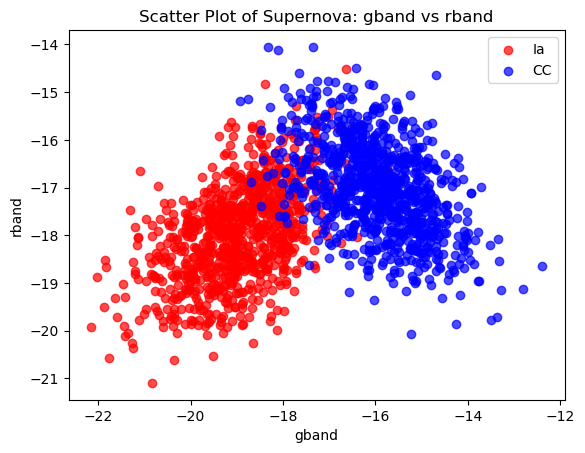

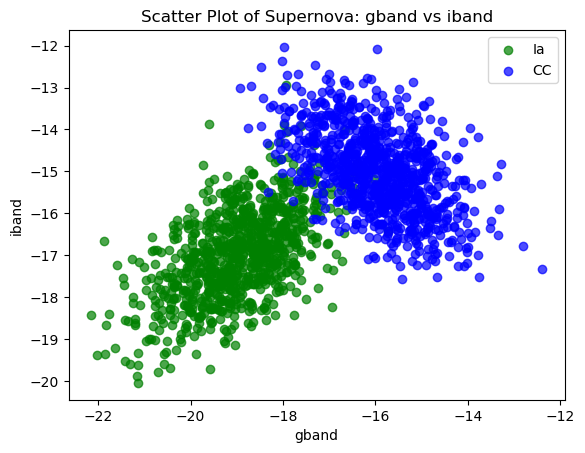

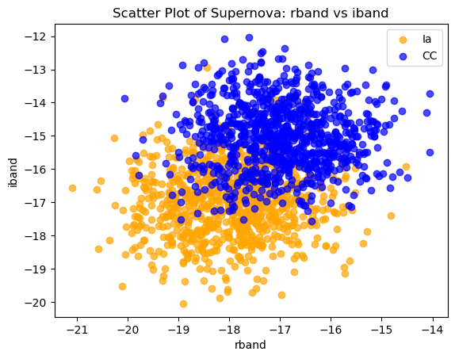

```python
#1a: Scatter Graphs
import pandas as pd
import matplotlib.pyplot as plt
import numpy as np

#Load data from txt file
file = "pset1-classification-training.txt"
columns = ["gband", "rband", "iband", "type"]
rfile = pd.read_csv(file, sep=r'\s+', names=columns)

print(rfile.head())
print(rfile.info())

#Colour code
colours = {'1a': 'red', 'CC': 'blue'}

#Use for loop to group data into respective types
for stype in rfile["type"].unique():
    subset = rfile[rfile["type"] == stype]
    plt.scatter(subset["gband"], subset["rband"],
        label=stype, color = colours.get(stype, 'red'), alpha = 0.7)


plt.legend()
plt.xlabel("gband")
plt.ylabel("rband")

plt.title("Scatter Plot of Supernova: gband vs rband")
plt.show()

#Use for loop to group data into respective types
for stype in rfile["type"].unique():
    subset = rfile[rfile["type"] == stype]
    plt.scatter(subset["gband"], subset["iband"],
        label=stype, color = colours.get(stype, 'green'), alpha = 0.7)


plt.legend()
plt.xlabel("gband")
plt.ylabel("iband")

plt.title("Scatter Plot of Supernova: gband vs iband")
plt.show()

#Use for loop to group data into respective types
for stype in rfile["type"].unique():
    subset = rfile[rfile["type"] == stype]
    plt.scatter(subset["rband"], subset["iband"],
        label=stype, color = colours.get(stype, 'orange'), alpha = 0.7)


plt.legend()
plt.xlabel("rband")
plt.ylabel("iband")

plt.title("Scatter Plot of Supernova: rband vs iband")
plt.show()
```

```python
#1b: Training Set Split
from sklearn.model_selection import train_test_split

train_set, verif_set = train_test_split(rfile, test_size=0.2, train_size=0.8, random_state=15, shuffle=True, stratify=None)
#Seperate to x and y

print("Training set:", train_set)
print("Verification set:", verif_set)
```

```
Training set:        gband   rband   iband type
1687 -16.651 -17.314 -14.678   CC
1653 -16.184 -16.871 -14.354   CC
514  -15.521 -17.511 -15.406   CC
1649 -16.861 -17.270 -14.788   CC
1562 -15.352 -18.547 -14.578   CC
...      ...     ...     ...  ...
156  -18.078 -17.124 -16.612   Ia
384  -17.018 -15.516 -16.707   Ia
645  -16.077 -15.983 -15.297   CC
1781 -15.369 -16.340 -14.347   CC
1480 -15.832 -16.802 -14.950   CC

[1440 rows x 4 columns]
Verification set:        gband   rband   iband type
732  -18.381 -18.460 -15.706   Ia
1016 -17.710 -17.910 -16.593   Ia
1571 -16.967 -15.662 -14.304   CC
1022 -17.981 -19.591 -16.508   Ia
1030 -16.380 -17.254 -15.147   CC
...      ...     ...     ...  ...
148  -14.773 -17.769 -14.746   CC
43   -17.940 -16.846 -15.958   Ia
657  -16.729 -15.777 -17.130   Ia
306  -19.091 -16.718 -15.446   Ia
1342 -18.896 -17.375 -17.405   Ia

[360 rows x 4 columns]
```

```python
#1c MOO Framework:
def my_model(theta, x):
    # Takes theta: vector of weights
    # Takes x: vector of features
    # Compute dot product θ and x
    dotprod = np.dot(x, theta)
    # Apply sigmoid
    probability_Ia = 1 / (1 + np.exp(-dotprod))

    return probability_Ia
```

```python
#1d Objective Function/Cross Entropy Score:

def my_objective_function(theta, x, y_true, smalle = 10 **(-10)):

    # Use model to predict y and then compare with true y
    y_predicted = my_model(theta, x)

    # Use clip to prevent 0 errors
    y_spredicted = np.clip(y_predicted, smalle, 1 - smalle)

    # Use definition of CE

    CE = -np.sum((y_true * np.log(y_spredicted)+(1-y_true)*np.log(1-y_spredicted)))
    cross_entropy_score = CE/len(y_true)
    return cross_entropy_score
```

```python
#1e Grid Search Optimisation:
# Set thetas to try
# Load data from txt file
file = "pset1-classification-training.txt"
columns = ["gband", "rband", "iband", "type"]
rfile = pd.read_csv(file, sep=r'\s+', names=columns)

x = train_set[["gband", "rband", "iband"]].values
y_true = (train_set["type"] == "Ia").astype(int).values  # Convert to array


theta1 = np.linspace(-1, 1, 20)
theta2 = np.linspace(-1, 1, 20)
theta3 = np.linspace(-1, 1, 20)

# Loss for each theta, find best
bestloss = 1000  # Initial guess
besttheta = ([1, 1, 1]) # Initial theta
for i in theta1:
    for j in theta2:
        for z in theta3:
            thetascore = my_objective_function((i, j, z), x, y_true, smalle = 10 **(-10)) #score for each combo

            if thetascore <= bestloss:
                besttheta = np.array([i, j, z])
                bestloss = thetascore

print("Best Cross Entropy Score:", bestloss)
print("Best theta:", besttheta)
```

```
Best Cross Entropy Score: 0.4982359105344759
Best theta: [-0.68421053  1.         -0.36842105]
```

For 1e: I used formulas/equations from class and applied them to the training set. I found the above results for Best Cross Entropy and Best theta.

```python
# 1f: Test on verif, to find number of positives/corrects
# Model on verif:
x2 = verif_set[["gband", "rband", "iband"]].values
probv_Ia = my_model(besttheta, x2)
#print(probv_1a) #gives array of prob

# Count amount of 1a supernovae predicted from model
count = 0
predictIa = []
for i in probv_Ia:
    if i >= 0.5:
        predictIa.append("Ia") # Create array of expected 1a
        count += 1
    else:
        predictIa.append("CC")
print("Predicted Ia Supernovae:", count)
print("Predicted labels:", predictIa)

# Compare to true:
matches = 0
for i,label in enumerate(predictIa):
    if label == verif_set["type"].iloc[i]:
        matches += 1

print("Matches Predicted Correctly:", matches)
total = len(verif_set) + 1
accuracy = (matches/total)*100
print("Accuracy:", accuracy, "%")
```

```
Predicted Ia Supernovae: 236
Predicted labels: ['CC', 'Ia', 'Ia', 'CC', 'CC', 'Ia', 'Ia', 'Ia', 'Ia', 'Ia', 'Ia', 'CC', 'Ia', 'CC', 'Ia', 'CC', 'Ia', 'Ia', 'Ia', 'Ia', 'CC', 'Ia', 'CC', 'Ia', 'CC', 'Ia', 'CC', 'Ia', 'CC', 'Ia', 'Ia', 'Ia', 'Ia', 'CC', 'Ia', 'Ia', 'Ia', 'Ia', 'CC', 'CC', 'Ia', 'CC', 'Ia', 'CC', 'CC', 'CC', 'Ia',…
Matches Predicted Correctly: 274
Accuracy: 75.90027700831024 %
```

```python
# 1g: Test set:

file = "pset1-classification-test.txt"
columns = ["gband", "rband", "iband", "type"]
rfile = pd.read_csv(file, sep=r'\s+', names=columns)

x = rfile[["gband", "rband", "iband"]].values
print("The theta we are using:", besttheta) # Check best theta from above is correctly stored
probtest = my_model(besttheta, x) # Array of predicted probabilities for Ia

testlabels = []
for i in probtest:
    if i >= 0.5:
        testlabels.append("Ia") # Create array of expected 1a
        count += 1
    else:
        testlabels.append("CC")
print(testlabels)

# Count predicted Ia
countIa = 0
countCC = 0

# Count occurrences
for label in testlabels:
    if label == "Ia":
        countIa += 1
    else:  # label must be CC
        countCC += 1

# Print results
print("Predicted Ia:", countIa)
print("Predicted CC:", countCC)
print("Predicted Ratio:", countCC/countIa)
```

```
The theta we are using: [-0.68421053  1.         -0.36842105]
['Ia', 'Ia', 'Ia', 'Ia', 'CC', 'Ia', 'CC', 'CC', 'CC', 'CC', 'Ia', 'CC', 'CC', 'Ia', 'CC', 'CC', 'Ia', 'Ia', 'Ia', 'Ia', 'Ia', 'Ia', 'Ia', 'CC', 'CC', 'CC', 'Ia', 'Ia', 'CC', 'CC', 'Ia', 'Ia', 'Ia', 'Ia', 'CC', 'CC', 'CC', 'Ia', 'Ia', 'Ia', 'CC', 'CC', 'CC', 'Ia', 'CC', 'Ia', 'Ia', 'Ia', 'Ia', 'CC',…
Predicted Ia: 133
Predicted CC: 67
Predicted Ratio: 0.5037593984962406
```

For Part 1g: I created an array of labels for the data from my model, so if they had a probabilty of +0.5, they were labelled Ia. If it was below they were labelled CC. I count hwow many total Ia and CC and then calculate ratio of CC/Ia

Bonus predict what fraction of Type Ia supernovae incorrectly classified as CC. Predict what fraction of CC supernovae incorrectly classified as Type Ia. We can look at the false positive and false negative rates as discussed in class, using confusion matrix fractions. I found the False Positive and False Negative rate, but I am not entirely sure how to implement them.

```python
# Miscalculated Ia:
TP = 0  # correct Ia
FN = 0  # incorrect Ia as CC
FP = 0  # incorrect CC as Ia
TN = 0  # correct CC

# Use similar loop from above to find pairs
for i, label in enumerate(predictIa):  #  predicted labels
    actual_label = verif_set["type"].iloc[i]  # actual labels

    if label == "Ia" and actual_label == "Ia":
        TP += 1  # Correct Type Ia
    elif label == "CC" and actual_label == "Ia":
        FN += 1  # Incorrect Ia as CC
    elif label == "Ia" and actual_label == "CC":
        FP += 1  # Incorrect CC as Ia
    elif label == "CC" and actual_label == "CC":
        TN += 1  # Correct CC

# Compute misclassification rates
FNR = FN / (TP + FN)   # Fraction of Ia incorrectly assigned CC
FPR = FP / (FP + TN)   # Fraction of CC incorrectly assigned Ia

print("False Negative Rate (Ia incorrectly assigned CC):", FNR)
print("False Positive Rate (CC incorrectly assigned Ia):", FPR)
```

```
False Negative Rate (Ia incorrectly assigned CC): 0.12121212121212122
False Positive Rate (CC incorrectly assigned Ia): 0.38271604938271603
```

Question 2: Measuring the Hubble Constant

```python
# Load file

file2 = "pset1-hubble.txt"
hfile = pd.read_csv(file2, sep=r'\s+', comment='#', names=["Supernova", "Redshift", "Distance", "Distance_Uncertainty"])

# Take 2nd, 3rd, 4th columns
redshift = hfile["Redshift"].values
distance = hfile["Distance"].values
distance_uncertainty = hfile["Distance_Uncertainty"].values
```

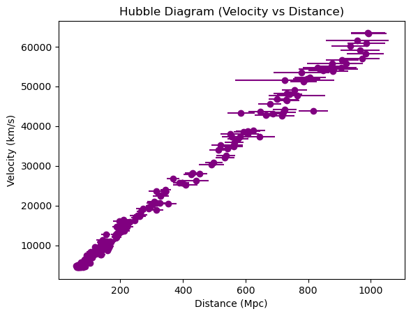

```python
# Hubble relation
c = 3 * 10**5 #km/s
v = c * redshift

# Plot Hubble
plt.errorbar(distance, v, xerr=distance_uncertainty, fmt='o', markerfacecolor = 'purple', color = 'purple')
plt.ylabel("Velocity (km/s)")
plt.xlabel("Distance (Mpc)")
plt.title("Hubble Diagram (Velocity vs Distance)")
plt.show()
```

```python
# Function for distance given velocity and Hubble constant:

def hub_model(v, H_0):
    #using d = v/H_0 relation
    return v / H_0
```

```python
# Objective Function: Negative Log-Likelihood
# Simplified as we did in class
def neg_log_likelihood(H_0, v, distance, distance_uncertainty):
    h_distance = hub_model(v, H_0)
    chi_squared = ((distance - h_distance) ** 2) / (2 * distance_uncertainty ** 2)
    log_likelihood = np.sum(chi_squared + 0.5 * np.log(2 * np.pi * distance_uncertainty ** 2))
    return log_likelihood
```

```python
# Define derivative of nll to then optimise
def nll_derivative(H_0, v, distance, distance_uncertainty, epsilon=1e-5):
    return (neg_log_likelihood(H_0 + epsilon, v, distance, distance_uncertainty) -
            neg_log_likelihood(H_0 - epsilon, v, distance, distance_uncertainty)) / (2 * epsilon)

# Use Gradient Descent without momentum
def gradient_descent(v, distance, distance_uncertainty, H0_init=70, learning_rate=0.01, epochs=1000, tol=1e-5, max_iter=1000):
    H_0 = H0_init  # Initial guess
    for i in range(max_iter): # Iterate
        grad = nll_derivative(H_0, v, distance, distance_uncertainty) # Gradient of NLL
        H_0 = H_0 - (learning_rate * grad) # Update H_0, opposite to gradient to find min
        if abs(grad) < tol:  # Stop if gradient is small as it does not change much (5dp)
            break
    return H_0

# Function to optimise
H0_best = gradient_descent(v, distance, distance_uncertainty)

print("Best estimate for H0:", H0_best)
```

```
Best estimate for H0: 66.83437147194809
```

```python
# Gradient Descent with Momentum
# possibly chnage epochs and max iter
# Use Gradient Descent with momentum
def mgradient_descent(v, distance, distance_uncertainty, H0_init=70, learning_rate=0.01, decay_rate = 0.5, epochs=1000, tol=1e-5, max_iter=1000):
    H_0 = H0_init  # Initial guess
    M_0 = 0 # Initial momentum
    for i in range(max_iter): # Iterate
        grad = nll_derivative(H_0, v, distance, distance_uncertainty) # Gradient of NLL
        M_0 = M_0 * decay_rate # Now introduce momentum, using decay rat e as another parameter
        H_0 = H_0 - (learning_rate * grad) + M_0 # Update H_0 now with momentum included
        if abs(grad) < tol:  # Stop if gradient is small as it does not change much (5dp)
            break
    return H_0

H0_mbest = mgradient_descent(v, distance, distance_uncertainty)
print("Best estimate for H0 with momentum:", H0_mbest)
```

```
Best estimate for H0 with momentum: 66.83437147194809
```

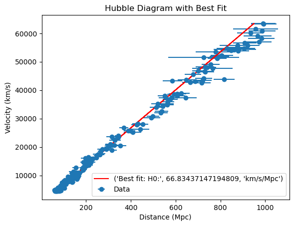

```
Best-fit H0: 66.83437147194809 km/s/Mpc
```

```python
# Plot best-fit model
plt.errorbar(distance, v, xerr=distance_uncertainty, fmt='o', label='Data')
plt.plot( hub_model(v, H0_best), v, label= ("Best fit: H0:", H0_best, "km/s/Mpc"), color='red' )
plt.ylabel("Velocity (km/s)")
plt.xlabel("Distance (Mpc)")
plt.title("Hubble Diagram with Best Fit")
plt.legend()
plt.show()

print("Best-fit H0:", H0_best,"km/s/Mpc")
```

```python
# Add history to Gradient Descent to track progress:
# Use Gradient Descent without momentum
def gradient_descent(v, distance, distance_uncertainty, H0_init=70, learning_rate=0.01, epochs=1000, tol=1e-5):
    H_0 = H0_init  # Initial guess
    hist = []
    for i in range(epochs): # Iterate
        grad = nll_derivative(H_0, v, distance, distance_uncertainty) # Gradient of NLL
        H_0 = H_0 - (learning_rate * grad) # Update H_0, opposite to gradient to find min
        hist.append(neg_log_likelihood(H_0, v, distance, distance_uncertainty))
        if abs(grad) < tol:  # Stop if gradient is small as it does not change much (5dp)
            break
    return H_0, hist

H_0, history_gd = gradient_descent(v, distance, distance_uncertainty)
print("Predicted H_0:", H_0)
print("Number of iterations:", len(history_gd))
```

```
Predicted H_0: 66.83437147194809
Number of iterations: 141
```

```python
# Gradient Descent with Momentum
def mgradient_descent(v, distance, distance_uncertainty, H0_init=70, learning_rate=0.01, decay_rate = 0.8, epochs=1000, tol=1e-5):
    H_0 = H0_init  # Initial guess
    M_0 = 0 # Initial momentum
    histm  = []
    for i in range(epochs): # Iterate
        grad = nll_derivative(H_0, v, distance, distance_uncertainty) # Gradient of NLL
        #M_0 = M_0 * decay_rate # Now introduce momentum, using decay rate as another parameter
        M_0 = decay_rate * M_0 + learning_rate * grad
        H_0 = H_0 - M_0
        histm.append(neg_log_likelihood(H_0, v, distance, distance_uncertainty))
        if abs(grad) < tol:  # Stop if gradient is small as it does not change much (5dp)
            break
    return H_0, histm


# Run gradient descent optimisation
H_0m, history_gdm = mgradient_descent(v, distance, distance_uncertainty)
print("Predicted H_0:", H_0m)
print("Number of iterations:", len(history_gdm))
```

```
Predicted H_0: 66.83437294836855
Number of iterations: 114
```

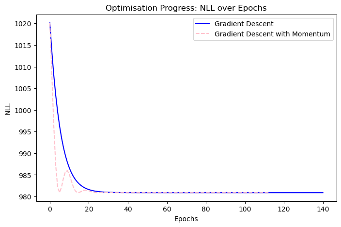

```python
H0_gd, history_gd = gradient_descent(v, distance, distance_uncertainty, epochs=1000)
H0_gdm, history_gdm = mgradient_descent(v, distance, distance_uncertainty, epochs=1000)
import matplotlib.pyplot as plt

plt.figure(figsize=(8,5))
plt.plot(history_gd, label='Gradient Descent', color='blue')
plt.plot(history_gdm, label='Gradient Descent with Momentum', color='pink', linestyle='dashed')
plt.xlabel("Epochs")
plt.ylabel("NLL")
plt.title("Optimisation Progress: NLL over Epochs")
plt.legend()
plt.show()
```

Gradient Descent with and without momentum. Here we can see that with momentum, we settle on a H_0 through less iterations so it is a faster process. The model updates and oscilliates towards the solutin. Both Gradient Descent with and without momentum lead to the same solution to 5 decimal places.

We can find the Hubble Constant through both methods:

```python
H_0, hist = gradient_descent(v, distance, distance_uncertainty, epochs=1000)
H_0m, histm = mgradient_descent(v, distance, distance_uncertainty, epochs=1000)
print("Hubble's Constant found without momentum:", H_0 , "km/s/Mpc")
print("Hubble's Constant found with momentum:" , H_0m , "km/s/Mpc")
```

```
Hubble's Constant found without momentum: 66.83437147194809 km/s/Mpc
Hubble's Constant found with momentum: 66.83437294836855 km/s/Mpc
```